# RWC19_Intestine_TF_List

The goal of this document is to compare publically available intestine expression datasets and summarize which transcription factors are present. This will then be used to generate a “hit list” of transcription factors to test function in the intestine.

To do:

- identify WBGene ID before merging to wTF3.0 for following data sets
- onish
- tintori
- add stage column to metadata table
- add sophie EMS data
- add dineen et al 2017 data

Pull in data. Paths are relative to where the R markdown file lives.

# A gene-centered C. elegans protein-DNA interaction network provides a framework for functional predictions.

## Fuxman Bass JI, Pons C, Kozlowski L, et al. Mol Syst Biol. 2016;12(10):884. doi:10.15252/MSB.20167131

```r
# worm transcription factor 3 database from the walhout lab
wTF3 <- read.delim("../02_Data/0_TF3_0/TF3-0_namesonly.txt", na.strings = c("", "NA"))
wTF3 <- wTF3 %>% select(Sequence.name, Public_name, WBGeneID, DBD) %>% na.omit()

# initialize blank dataframe
int_TF_df <- data.frame()
```

Make Seprate “metadata” dataframe to store descriptive information

```r
RWC19_Metadata <- data.frame(column_ID = colnames(wTF3))

RWC19_Metadata <- RWC19_Metadata %>%
  mutate(column_detail = c("Cosmid, fosmid or YAC derived gene name", "Accepted gene name", "Unique wormbase accession number", "DNA binding domain")) %>%
  mutate(source_DOI = "10.15252/msb.20167131") %>%
  mutate(source_detail = "Dataset EV3") %>%
  mutate(seq_method = "NA")
```

# Adult Hand dissected intestines

```r
# TFs from Erin's adult intestine RNA-seq that I processed. see `intestine_tfs.Rmd`
onish_adult <- read.csv("../02_Data/8_Hand_Dissected_Adult_Intestine_RNA-seq/171214_res_gutsVwt_DESeq.csv")

# give the columns orgin-relevant names
colnames(onish_adult) <- str_c("onish_adult_",colnames(onish_adult))

# check to make sure it looks right
#View(onish_adult)

# Determine if gene is enriched. Log2(FC) greater than 0 and p adjusted value below 0.05
onish_adult_enriched <- onish_adult %>% filter(onish_adult$onish_adult_log2FoldChange >= 0, onish_adult$onish_adult_padj <= 0.05)

# merge to master dataframe. If the TF is not in the dataset, give the row values an NA
int_TF_df <- merge(x = wTF3, y = onish_adult_enriched, by.x = "Sequence.name", by.y = "onish_adult_Gene", all.x = T)

# create a boolean TRUE/FALSE column if it is present in the intestine.
int_TF_df <- int_TF_df %>% mutate(onish_adult_bool = if_else(int_TF_df$Sequence.name %in% onish_adult_enriched$onish_adult_Gene, TRUE, FALSE))

# update metadata

RWC19_Metadata <- RWC19_Metadata %>% add_row(
  column_ID = colnames(onish_adult_enriched[1]),
  column_detail = "Sequence name from UCSC GTF file",
  source_DOI = "unpublsihed",
  source_detail = "RNA-seq of hand dissected adult intestine from the McGhee lab",
  seq_method = "Illumina"
  ) %>% add_row(
  column_ID = colnames(onish_adult_enriched[2]),
  column_detail = "Mean expression of gene determined by DESeq2",
  source_DOI = "unpublsihed",
  source_detail = "RNA-seq of hand dissected adult intestine from the McGhee lab",
  seq_method = "Illumina"
  ) %>% add_row(
  column_ID = colnames(onish_adult_enriched[3]),
  column_detail = "Log2(Fold Change) of gene determined by DESeq2. Greater than zero is enriched in the intestine. Less than zero is enriched in whole adult worms",
  source_DOI = "unpublsihed",
  source_detail = "RNA-seq of hand dissected adult intestine from the McGhee lab",
  seq_method = "Illumina"
  ) %>% add_row(
  column_ID = colnames(onish_adult_enriched[4]),
  column_detail = "Log2(Fold Change) unshrunken maximum likelihood estimate of gene determined by DESeq2. Used for plots and gene ranks",
  source_DOI = "unpublsihed",
  source_detail = "RNA-seq of hand dissected adult intestine from the McGhee lab",
  seq_method = "Illumina"
  ) %>% add_row(
  column_ID = colnames(onish_adult_enriched[5]),
  column_detail = "Wald statistic of gene determined by DESeq2",
  source_DOI = "unpublsihed",
  source_detail = "RNA-seq of hand dissected adult intestine from the McGhee lab",
  seq_method = "Illumina"
  ) %>% add_row(
  column_ID = colnames(onish_adult_enriched[6]),
  column_detail = "p-value of gene determined by DESeq2",
  source_DOI = "unpublsihed",
  source_detail = "RNA-seq of hand dissected adult intestine from the McGhee lab",
  seq_method = "Illumina"
  ) %>% add_row(
  column_ID = colnames(onish_adult_enriched[7]),
  column_detail = "Adjusted p-value of gene determined by DESeq2",
  source_DOI = "unpublsihed",
  source_detail = "RNA-seq of hand dissected adult intestine from the McGhee lab",
  seq_method = "Illumina"
  )
```

# A Transcriptional Lineage of the Early C . elegans Embryo.

## Tintori SC, Nishimura EO, Golden P, Lieb JD, Goldstein B. Dev Cell. 2016;38(4):430-444. doi:10.1101/047746

```r
# Transcripts from embryonic 1E intestine from Sophie's single cell RNA-seq paper. See `intestine_tfs.Rmd`
tintori_columns <- c("gene", "p.value", "log.CPM", "log.FC")
tintori_1E <- read.csv("../02_Data/7_Tintori_et_al_2016_Embryo_scRNA-seq/8cell_vs_1E_p1_00.csv")
colnames(tintori_1E) <- str_c("tintori_1E_", tintori_columns)

int_TF_df <- merge(x = int_TF_df, y = tintori_1E, by.x = "Public_name", by.y = "tintori_1E_gene", all.x = T)

# Add boolian column such that it is true if log(FC) is greater than zero and p-value less than 0.05

tintori_1E_enriched <- int_TF_df %>% filter(int_TF_df$tintori_1E_p.value <= 0.05, int_TF_df$tintori_1E_log.FC < 0)

int_TF_df <- int_TF_df %>% mutate(tintori_1E_bool = if_else(int_TF_df$WBGeneID %in% tintori_1E_enriched$WBGeneID, TRUE, FALSE))

# Transcripts from embryonic 2Ep intestine from Sophie's single cell RNA-seq paper. See `intestine_tfs.Rmd`
tintori_2Ep <- read.csv("../02_Data/7_Tintori_et_al_2016_Embryo_scRNA-seq/16cell_vs_Ep_p1_00.csv")
colnames(tintori_2Ep) <- str_c("tintori_2Ep_", tintori_columns)

int_TF_df <- merge(x = int_TF_df, y = tintori_2Ep, by.x = "Public_name", by.y = "tintori_2Ep_gene", all.x = T)

# Add boolian column such that it is true if log(FC) is greater than zero and p-value less than 0.05
tintori_2Ep_enriched <- int_TF_df %>% filter(int_TF_df$tintori_2Ep_p.value <= 0.05 & int_TF_df$tintori_2Ep_log.FC < 0)

int_TF_df <- int_TF_df %>% mutate(tintori_2Ep_bool = if_else(int_TF_df$WBGeneID %in% tintori_2Ep_enriched$WBGeneID, TRUE, FALSE))

# Update metadata

RWC19_Metadata <- RWC19_Metadata %>% add_row(
  column_ID = colnames(tintori_1E[1]),
  column_detail = "Gene sequence name",
  source_DOI = "10.1016/j.devcel.2016.07.025",
  source_detail = "Single cell RNA-seq of hand dissected embryo. Accessed from tintori.bio.unc.edu.",
  seq_method = "Illumina"
  ) %>% add_row(
  column_ID = colnames(tintori_1E[2]),
  column_detail = "Gene p-value",
  source_DOI = "10.1016/j.devcel.2016.07.025",
  source_detail = "Single cell RNA-seq of hand dissected embryo. Accessed from tintori.bio.unc.edu.",
  seq_method = "Illumina"
  ) %>% add_row(
  column_ID = colnames(tintori_1E[3]),
  column_detail = "Counts per transcript per million mapped reads.",
  source_DOI = "10.1016/j.devcel.2016.07.025",
  source_detail = "Single cell RNA-seq of hand dissected embryo. Accessed from tintori.bio.unc.edu.",
  seq_method = "Illumina"
  ) %>% add_row(
  column_ID = colnames(tintori_1E[4]),
  column_detail = "Log2(Fold Change) of gene in the 1E cell when compared to the whole embryo. Less than zero is enriched in the 1E cell. Greater than zero is enriched in the whole 8 cell embryo",
  source_DOI = "10.1016/j.devcel.2016.07.025",
  source_detail = "Single cell RNA-seq of hand dissected embryo. Accessed from tintori.bio.unc.edu.",
  seq_method = "Illumina"
  )

RWC19_Metadata <- RWC19_Metadata %>% add_row(
  column_ID = colnames(tintori_2Ep[1]),
  column_detail = "Gene sequence name",
  source_DOI = "10.1016/j.devcel.2016.07.025",
  source_detail = "Single cell RNA-seq of hand dissected embryo. Accessed from tintori.bio.unc.edu.",
  seq_method = "Illumina"
  ) %>% add_row(
  column_ID = colnames(tintori_2Ep[2]),
  column_detail = "Gene p-value",
  source_DOI = "10.1016/j.devcel.2016.07.025",
  source_detail = "Single cell RNA-seq of hand dissected embryo. Accessed from tintori.bio.unc.edu.",
  seq_method = "Illumina"
  ) %>% add_row(
  column_ID = colnames(tintori_2Ep[3]),
  column_detail = "Counts per transcript per million mapped reads.",
  source_DOI = "10.1016/j.devcel.2016.07.025",
  source_detail = "Single cell RNA-seq of hand dissected embryo. Accessed from tintori.bio.unc.edu.",
  seq_method = "Illumina"
  ) %>% add_row(
  column_ID = colnames(tintori_2Ep[4]),
  column_detail = "Log2(Fold Change) of gene in the 2Ep cell when compared to the whole embryo. Less than zero is enriched in the 1E cell. Greater than zero is enriched in the whole 16 cell embryo",
  source_DOI = "10.1016/j.devcel.2016.07.025",
  source_detail = "Single cell RNA-seq of hand dissected embryo. Accessed from tintori.bio.unc.edu.",
  seq_method = "Illumina"
  )
```

# A lineage-resolved molecular atlas of C. elegans embryogenesis at single cell resolution

## Jonathan S. Packer, Qin Zhu, Chau Huynh, Priya Sivaramakrishnan, Elicia Preston, Hannah Dueck, Derek Stefanik, Kai Tan, Cole Trapnell, Junhyong Kim, Robert H. Waterston, John I. Murray doi: https://doi.org/10.1101/565549

```r
#Do not use this data yet. Unpublished and difficult to interpret what all the columns are...

# TFs from embryo single cell RNA-seq (Packer et al 2019)
#packer_s7_tbl <- readRDS("../../10_DATASETS/11_Packer_et_al_2019_Lineage_Resolved_Embryo/s7_tbl.rds")

#packer_Exx <- packer_s7_tbl %>% filter(lineage == c("Exx"))
#colnames(packer_Exx) <- str_c("packer_Exx_", colnames(packer_Exx))

#colnames(packer_Exx)

#int_TF_df <- merge(x = int_TF_df, y = packer_Exx, by.x = "WBGeneID", by.y = "packer_Exx_gene.id", all.x = T)



#packer_Exxx <- packer_s7_tbl %>% filter(lineage == c("Exxx"))
#colnames(packer_Exxx) <- str_c("packer_Exxx_", colnames(packer_Exxx))

#View(merge(x = int_TF_df, y = packer_Exxx, by.x = "WBGeneID", by.y = "packer_Exxx_gene.id", all.x = T))
```

# Spatiotemporal transcriptomics reveals the evolutionary history of the endoderm germ layer.

## Hashimshony T, Feder M, Levin M, Hall BK, Yanai I. Nature. 2015;519(7542):219-222. doi:10.1038/nature13996

```r
# TFs from Hashimshony endoderm genes
hashimshony_embryo <- read.csv("../02_Data/1_Hashimshony_et_al_2015_CEL-seq/Hashimshony_Endoderm_Genes.csv", header = TRUE)
colnames(hashimshony_embryo) <- c("hashimshony_embryo_genes")
int_TF_df <- int_TF_df %>% mutate(hashimshony_embryo_bool = if_else(int_TF_df$Public_name %in% hashimshony_embryo$hashimshony_embryo_genes, TRUE, FALSE))

# Update metadata

RWC19_Metadata <- RWC19_Metadata %>% add_row(
  column_ID = colnames(hashimshony_embryo[1]),
  column_detail = "Gene public name",
  source_DOI = "10.1038/nature13996",
  source_detail = "Supplementary Table 4. Endoderm gene set from Single cell RNA-seq of cultured dissociated embryos.",
  seq_method = "Illumina"
  )
```

# Comparative RNA-Seq analysis reveals pervasive tissue-specific alternative polyadenylation in Caenorhabditis elegans intestine and muscles.

## Blazie SM, Babb C, Wilky H, Rawls A, Park JG, Mangone M. BMC Biol. 2015;13(1):4. doi:10.1186/s12915-015-0116-6

```r
# Tfs from Blaize et al PAB-1 pulldown
blazieGenes <- read_excel("../02_Data/2_Blazie_et_al_2015_PAB-1_Pulldown_RNA-seq/Blazie_et_al_2015_Table_S3_ges-1_all_genes.xlsx")
blazieGenesSubset <- data.frame(blazie_WBGeneID = blazieGenes[1], blazie_FPKM = blazieGenes[8])
colnames(blazieGenesSubset) <- c("blazie_mixed_WBGeneID", "blazie_mixed_FPKM")

#View(blaizeGenesSubset)
int_TF_df <- merge(x = int_TF_df, y = blazieGenesSubset, by.x = "WBGeneID", by.y = "blazie_mixed_WBGeneID", all.x = TRUE)

# add boolian column
int_TF_df <- int_TF_df %>% mutate(blazie_mixed_bool = if_else(int_TF_df$WBGeneID %in% blazieGenesSubset$blazie_mixed_WBGeneID, TRUE, FALSE))

# update metadata

RWC19_Metadata <- RWC19_Metadata %>% add_row(
  column_ID = colnames(blazieGenesSubset[1]),
  column_detail = "Wormbase Gene ID",
  source_DOI = "10.1186/s12915-015-0116-6",
  source_detail = "Table S3. RNA-seq of ges-1P::PAB-1 pulldown"
  ) %>% add_row(
  column_ID = colnames(blazieGenesSubset[2]),
  column_detail = "Fragments per thousand base pairs per million mapped reads",
  source_DOI = "10.1186/s12915-015-0116-6",
  source_detail = "Table S3. RNA-seq of ges-1P::PAB-1 pulldown",
  seq_method = "Illumina"
  )
```

# Analysis of C. elegans intestinal gene expression and polyadenylation by fluorescence-activated nuclei sorting and 3′-end-seq.

## 1. Haenni S, Ji Z, Hoque M, et al. Nucleic Acids Res. 2012;40(13):6304-6318. doi:10.1093/nar/gks282

```r
# TFs from Haenni et al intestine FANS
haenniGenes <- read.csv("../02_Data/3_Haenni_et_al_Intestine_Nuclei_3end-seq/gks282_supplementary_data/nar-00455-f-2012-File008.csv", header = TRUE)

# compute log2 fold change of the RPM value between "Sorted" intestine cells and "Unsorted"
haenniGenes <- haenniGenes %>% mutate(log2RPM = log2(haenniGenes$Sorted..RPM.+0.01)/(haenniGenes$Unsorted..RPM.+0.01))
colnames(haenniGenes) <- c("gene", "geneID", "refID", "chrom", "strand", "unsorted", "sorted", "pvalue", "group", "log2RPM")
colnames(haenniGenes) <- str_c("haenni_mixed_", colnames(haenniGenes))
haenni_subset <- data.frame(haenniGenes[1], haenniGenes[6], haenniGenes[7], haenniGenes[8], haenniGenes[9], haenniGenes[10])

#add to master dataframe
int_TF_df <- merge(x = int_TF_df, y = haenni_subset, by.x = "Sequence.name", by.y = "haenni_mixed_gene", all.x = TRUE)

# compute boolian present/absent column based on authors grouping
haenni_subset_intestine <- haenni_subset %>% filter(haenni_mixed_group == "Sorted")
int_TF_df <- int_TF_df%>% mutate(haenni_FANS_bool = if_else(int_TF_df$Sequence.name %in% haenni_subset_intestine$haenni_mixed_gene, TRUE, FALSE))


RWC19_Metadata <- RWC19_Metadata  %>% add_row(
  column_ID = colnames(haenni_subset[1]),
  column_detail = "Wormbase Gene ID",
  source_DOI = "10.1093/nar/gks282",
  source_detail = "Supplementay File 8. RNA-seq of ges-1P::PAB-1 pulldown",
  seq_method = "Illumina"
  ) %>% add_row(
  column_ID = colnames(haenni_subset[2]),
  column_detail = "RPM of total nuclei in mixed stage worms",
  source_DOI = "10.1093/nar/gks282",
  source_detail = "Table S3. RNA-seq of ges-1P::PAB-1 pulldown",
  seq_method = "Illumina"
  ) %>% add_row(
  column_ID = colnames(haenni_subset[3]),
  column_detail = "RPM of intestine enriched nuclei in mixed stage worms. Sorting based on elt-2P::GFP::H2B JM149",
  source_DOI = "10.1093/nar/gks282",
  source_detail = "Table S3. RNA-seq of ges-1P::PAB-1 pulldown",
  seq_method = "Illumina"
  )%>% add_row(
  column_ID = colnames(haenni_subset[4]),
  column_detail = "Fisher's exact p-value of intestine enriched genes",
  source_DOI = "10.1093/nar/gks282",
  source_detail = "Table S3. RNA-seq of ges-1P::PAB-1 pulldown",
  seq_method = "Illumina"
  ) %>% add_row(
  column_ID = colnames(haenni_subset[5]),
  column_detail = "Categorization of genes. Sorted = intestine enriched, Unsorted = whole worm enriched, Other = somewhere in the middle? ",
  source_DOI = "10.1093/nar/gks282",
  source_detail = "Table S3. RNA-seq of ges-1P::PAB-1 pulldown",
  seq_method = "Illumina"
  ) %>% add_row(
  column_ID = colnames(haenni_subset[6]),
  column_detail = "Log2(Sorted RPM/Unsorted RPM). Greater than zero is intestine enriched, less than zero is whole worm enriched",
  source_DOI = "10.1093/nar/gks282",
  source_detail = "Table S3. RNA-seq of ges-1P::PAB-1 pulldown",
  seq_method = "Illumina"
  ) %>% add_row(
  column_ID = "haenni_FANS_bool",
  column_detail = "True if in the 'Sorted' group ",
  source_DOI = "10.1093/nar/gks282",
  source_detail = "Table S3. RNA-seq of ges-1P::PAB-1 pulldown",
  seq_method = "Illumina"
  )
```

# Chromosomal clustering and GATA transcriptional regulation of intestine-expressed genes in C. elegans.

## Pauli F, Liu Y, Kim Y a, Chen P-J, Kim SK. Development. 2006;133(2):287-295. doi:10.1242/dev.02185

```r
# TFs from Pauli et al
pauliGenes <- read_excel("../02_Data/4_Pauli_et_al_2006_PAB-1_Pulldown_microarray/SupTable1_intestine_enriched_genes.xlsx")
colnames(pauliGenes) <- str_c("pauli_L4_", c("gene", "percentile", "pvalue", "description"))

# add to master datatable

int_TF_df <- merge(x = int_TF_df, y = pauliGenes, by.x = "Sequence.name", by.y = "pauli_L4_gene", all.x = TRUE)

# make boolian column
int_TF_df <- int_TF_df %>% mutate(pauli_L4_bool = if_else(int_TF_df$Sequence.name %in% pauliGenes$pauli_L4_gene, TRUE, FALSE))

# update metadata
RWC19_Metadata <- RWC19_Metadata  %>% add_row(
  column_ID = colnames(pauliGenes[1]),
  column_detail = "Sequence name",
  source_DOI = "10.1242/dev.02185",
  source_detail = "Supplementary Table 1. Microarray of ges-1P::PAB-1 pulldown in L4 worms"
  ) %>% add_row(
  column_ID = colnames(pauliGenes[2]),
  column_detail = "Percentile ranking of transcript abundance",
  source_DOI = "10.1242/dev.02185",
  source_detail = "Supplementary Table 1. Microarray of ges-1P::PAB-1 pulldown in L4 worms"
  ) %>% add_row(
  column_ID = colnames(pauliGenes[3]),
  column_detail = "Student's T-test to calculate significant enrichment of intestine transcripts",
  source_DOI = "10.1242/dev.02185",
  source_detail = "Supplementary Table 1. Microarray of ges-1P::PAB-1 pulldown in L4 worms"
  ) %>% add_row(
  column_ID = colnames(pauliGenes[4]),
  column_detail = "Short descriptions generated by WormBase",
  source_DOI = "10.1242/dev.02185",
  source_detail = "Supplementary Table 1. Microarray of ges-1P::PAB-1 pulldown in L4 worms"
  ) %>% add_row(
  column_ID = "pauli_L4_bool",
  column_detail = "True if included on the list, false if absent on the list",
  source_DOI = "10.1242/dev.02185",
  source_detail = "Supplementary Table 1. Microarray of ges-1P::PAB-1 pulldown in L4 worms"
  )

# add sequencing method column

RWC19_Metadata <- mutate(RWC19_Metadata, seq_method = ifelse(RWC19_Metadata$column_ID %in% c(colnames(pauliGenes), "pauli_L4_bool"), "Microarray",RWC19_Metadata$seq_method))

# subset the pauli rows with `ifelse` and `%in%`, replace the NA in `seq_method` with "Microarray"
# if the value does not come from pauli, then place the original string from RWC19_Metadata
```

# A spatial and temporal map of C. elegans gene expression. Genome Research, 21(2), 325–41. https://doi.org/10.1101/gr.114595.110

## Spencer, W. C., Zeller, G., Watson, J. D., Henz, S. R., Watkins, K. L., McWhirter, R. D., … Miller, D. M. (2011).

```r
# Late embryo intestine from Spencer et al
spencerLEgenes <- read.table("../02_Data/6_Spencer_et_al_2010_FACS_and_pulldown_tilling_array/LE-intestine_enr_vs_ref.WS200.txt", quote="\"", comment.char="", header = TRUE)
colnames(spencerLEgenes) <- str_c("spencer_LE_", colnames(spencerLEgenes))
spencer_LE_subset <- spencerLEgenes %>% select(spencer_LE_ID, spencer_LE_AveExpr, spencer_LE_adj_P_Val, spencer_LE_FC)

# add to dataframe
int_TF_df <- merge(x = int_TF_df, y = spencer_LE_subset, by.x = 'WBGeneID', by.y = 'spencer_LE_ID', all.x = TRUE)

# create true/false if gene is on list
int_TF_df <- int_TF_df %>% mutate(spencer_LE_bool = if_else(int_TF_df$WBGeneID %in% spencer_LE_subset$spencer_LE_ID, TRUE, FALSE))


# L2 intestine genes from Spencer et al
spencerL2genes <- read.table("../02_Data/6_Spencer_et_al_2010_FACS_and_pulldown_tilling_array/L2-intestine_enr_vs_ref.WS200.txt", quote="\"", comment.char="", header = TRUE)
colnames(spencerL2genes) <- str_c("spencer_L2_", colnames(spencerL2genes))
spencer_L2_subset <- spencerL2genes %>% select(spencer_L2_ID, spencer_L2_AveExpr, spencer_L2_adj_P_Val, spencer_L2_FC)

int_TF_df <- merge(x = int_TF_df, y = spencer_L2_subset, by.x = 'WBGeneID', by.y = 'spencer_L2_ID', all.x = TRUE)
int_TF_df <- int_TF_df %>% mutate(spencer_L2_bool = if_else(int_TF_df$WBGeneID %in% spencer_L2_subset$spencer_L2_ID, TRUE, FALSE))

# Update metadata

RWC19_Metadata <- RWC19_Metadata  %>% add_row(
  column_ID = colnames(spencer_LE_subset[1]),
  column_detail = "Wormbase Gene ID",
  source_DOI = "10.1101/gr.114595.110",
  source_detail = "FACS Sorted ELT-2::GFP worms. https://www.vanderbilt.edu/wormdoc/wormmap"
  ) %>% add_row(
  column_ID = colnames(spencer_LE_subset[2]),
  column_detail = "??",
  source_DOI = "10.1101/gr.114595.110",
  source_detail = "FACS Sorted ELT-2::GFP worms. https://www.vanderbilt.edu/wormdoc/wormmap"
  ) %>% add_row(
  column_ID = colnames(spencer_LE_subset[3]),
  column_detail = "??",
  source_DOI = "10.1101/gr.114595.110",
  source_detail = "FACS Sorted ELT-2::GFP worms. https://www.vanderbilt.edu/wormdoc/wormmap"
  ) %>% add_row(
  column_ID = colnames(spencer_LE_subset[4]),
  column_detail = "??",
  source_DOI = "10.1101/gr.114595.110",
  source_detail = "FACS Sorted ELT-2::GFP worms. https://www.vanderbilt.edu/wormdoc/wormmap"
  ) %>% add_row(
  column_ID = "spencer_LE_bool",
  column_detail = "True if present in this list",
  source_DOI = "10.1101/gr.114595.110",
  source_detail = "FACS Sorted ELT-2::GFP worms. https://www.vanderbilt.edu/wormdoc/wormmap"
  )

RWC19_Metadata <- mutate(RWC19_Metadata, seq_method = ifelse(RWC19_Metadata$column_ID %in% c(colnames(spencer_LE_subset), "spencer_LE_bool"), "Microarray",RWC19_Metadata$seq_method))

RWC19_Metadata <- RWC19_Metadata  %>% add_row(
  column_ID = colnames(spencer_L2_subset[1]),
  column_detail = "Wormbase Gene ID",
  source_DOI = "10.1101/gr.114595.110",
  source_detail = "FACS Sorted ELT-2::GFP worms. https://www.vanderbilt.edu/wormdoc/wormmap"
  ) %>% add_row(
  column_ID = colnames(spencer_L2_subset[2]),
  column_detail = "??",
  source_DOI = "10.1101/gr.114595.110",
  source_detail = "FACS Sorted ELT-2::GFP worms. https://www.vanderbilt.edu/wormdoc/wormmap"
  ) %>% add_row(
  column_ID = colnames(spencer_L2_subset[3]),
  column_detail = "??",
  source_DOI = "10.1101/gr.114595.110",
  source_detail = "FACS Sorted ELT-2::GFP worms. https://www.vanderbilt.edu/wormdoc/wormmap"
  ) %>% add_row(
  column_ID = colnames(spencer_L2_subset[4]),
  column_detail = "??",
  source_DOI = "10.1101/gr.114595.110",
  source_detail = "FACS Sorted ELT-2::GFP worms. https://www.vanderbilt.edu/wormdoc/wormmap"
  ) %>% add_row(
  column_ID = "spencer_L2_bool",
  column_detail = "True if present in this list",
  source_DOI = "10.1101/gr.114595.110",
  source_detail = "FACS Sorted ELT-2::GFP worms. https://www.vanderbilt.edu/wormdoc/wormmap"
  )

RWC19_Metadata <- mutate(RWC19_Metadata, seq_method = ifelse(RWC19_Metadata$column_ID %in% c(colnames(spencer_L2_subset), "spencer_L2_bool"), "Microarray",RWC19_Metadata$seq_method))
```

# Quantitating transcription factor redundancy: The relative roles of the ELT-2 and ELT-7 GATA factors in the C. elegans endoderm. Developmental Biology, 435(2), 150–161. https://doi.org/10.1016/J.YDBIO.2017.12.023

## Dineen, A., Osborne Nishimura, E., Goszczynski, B., Rothman, J. H., & McGhee, J. D. (2018).

```r
# coming soon...
```

# ELT-2 stage specific Binding Data

```r
ELT2_EE_LE_L3_Peaks <- read.delim("../02_Data/valerie_peaks_processed.bedlike")

ELT2_peak_k1 <- ELT2_EE_LE_L3_Peaks %>% filter(kclust_mapping == 1) %>% select(WBID) %>% na.omit() %>% unique()
ELT2_peak_k2 <- ELT2_EE_LE_L3_Peaks %>% filter(kclust_mapping == 2) %>% select(WBID) %>% na.omit() %>% unique()
ELT2_peak_k3 <- ELT2_EE_LE_L3_Peaks %>% filter(kclust_mapping == 3) %>% select(WBID) %>% na.omit() %>% unique()
ELT2_peak_k4 <- ELT2_EE_LE_L3_Peaks %>% filter(kclust_mapping == 4) %>% select(WBID) %>% na.omit() %>% unique()
ELT2_peak_k_na <- ELT2_EE_LE_L3_Peaks %>% filter(is.na(kclust_mapping)) %>% select(WBID) %>% na.omit() %>% unique()

class(ELT2_peak_k1)
```

```
## [1] "data.frame"
```

```r
# Add to dataframe

int_TF_df <- int_TF_df %>% mutate(ELT2_peak_k1_bool = if_else(int_TF_df$WBGeneID %in% ELT2_peak_k1$WBID, TRUE, FALSE))
int_TF_df <- int_TF_df %>% mutate(ELT2_peak_k2_bool = if_else(int_TF_df$WBGeneID %in% ELT2_peak_k2$WBID, TRUE, FALSE))
int_TF_df <- int_TF_df %>% mutate(ELT2_peak_k3_bool = if_else(int_TF_df$WBGeneID %in% ELT2_peak_k3$WBID, TRUE, FALSE))
int_TF_df <- int_TF_df %>% mutate(ELT2_peak_k4_bool = if_else(int_TF_df$WBGeneID %in% ELT2_peak_k4$WBID, TRUE, FALSE))
int_TF_df <- int_TF_df %>% mutate(ELT2_peak_k_na_bool = if_else(int_TF_df$WBGeneID %in% ELT2_peak_k_na$WBID, TRUE, FALSE))
```

# Export the dataframe

```r
write.csv(int_TF_df, "./intestine_TF_database.csv")
write.csv(RWC19_Metadata, "./intestine_TF_metadata.csv")
```

# Manipulations

Now make a master table that records presence/absence in these data sets

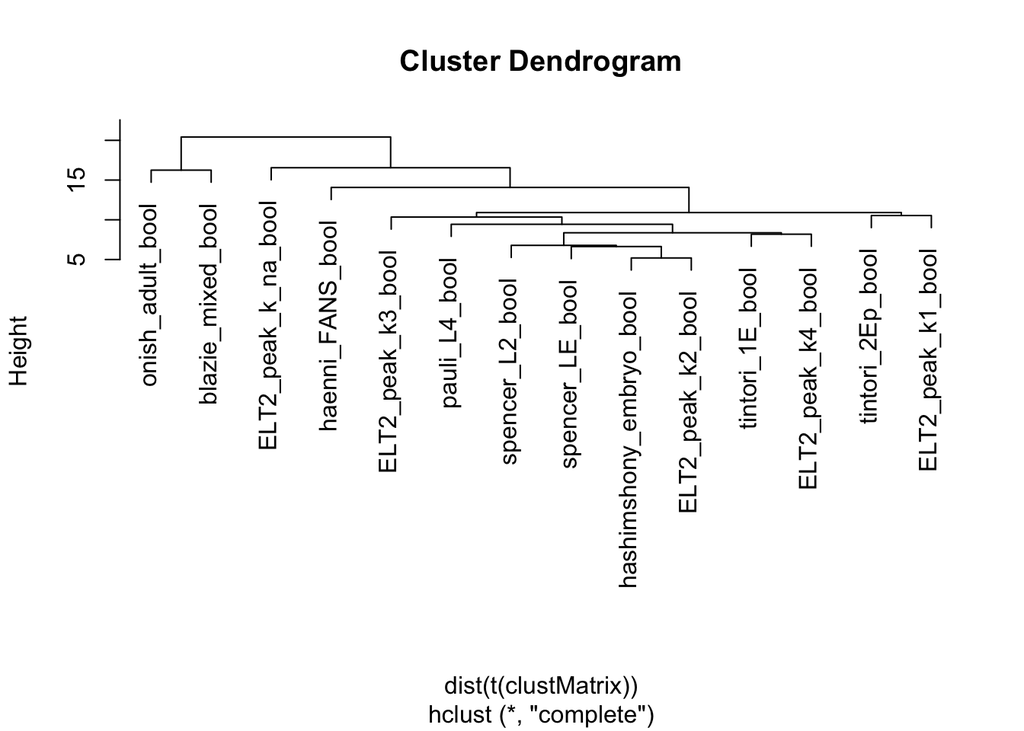

```r
clustMatrix <- int_TF_df %>% select(hashimshony_embryo_bool, pauli_L4_bool, spencer_LE_bool, spencer_L2_bool, tintori_1E_bool, tintori_2Ep_bool, onish_adult_bool, haenni_FANS_bool, blazie_mixed_bool, ELT2_peak_k1_bool, ELT2_peak_k2_bool, ELT2_peak_k3_bool, ELT2_peak_k4_bool, ELT2_peak_k_na_bool)
rownames(clustMatrix) <- int_TF_df$WBGeneID

clustMatrixZeroOne <- data.frame(ifelse(clustMatrix == TRUE, 1,0), WBGeneID = int_TF_df$WBGeneID)

plot(hclust(dist(t(clustMatrix))))
```

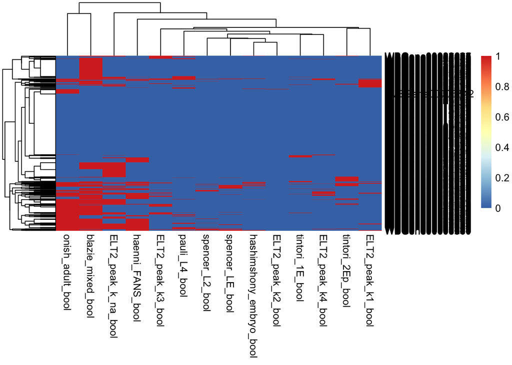

```r
pheatmap(clustMatrixZeroOne[,1:14])
```

```r
nonzeroClustMatrixZeroOne <- clustMatrixZeroOne %>% filter(haenni_FANS_bool == 1 | hashimshony_embryo_bool == 1 | spencer_LE_bool == 1 | spencer_L2_bool == 1 | tintori_1E_bool == 1 | tintori_2Ep_bool == 1 | onish_adult_bool == 1 | haenni_FANS_bool == 1 | blazie_mixed_bool ==1 | ELT2_peak_k1_bool == 1 | ELT2_peak_k2_bool == 1 | ELT2_peak_k3_bool == 1 | ELT2_peak_k4_bool == 1 | ELT2_peak_k_na_bool == 1) # removes rows that have zero for all columns
dim(nonzeroClustMatrixZeroOne)
```

```
## [1] 609  15
```

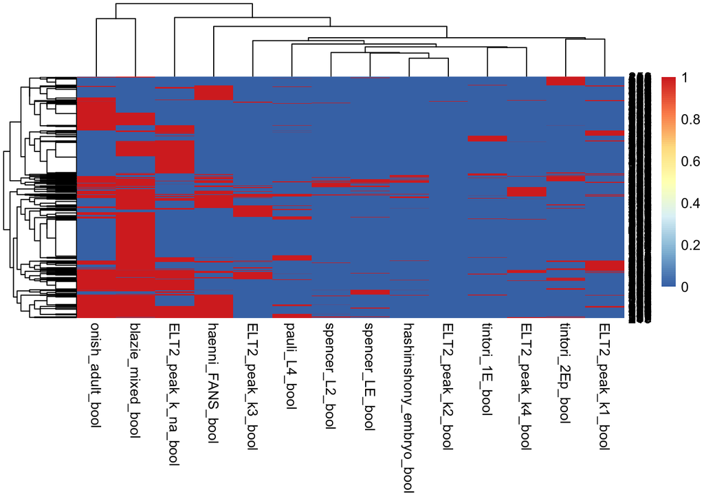

```r
pheatmap(nonzeroClustMatrixZeroOne[,1:14])
```

```r
clustMatrixZeroOne %>% filter(ELT2_peak_k4_bool == 1)
```

```
##    hashimshony_embryo_bool pauli_L4_bool spencer_LE_bool spencer_L2_bool
## 1                        0             1               0               1
## 2                        0             0               0               0
## 3                        0             1               0               0
## 4                        0             0               0               0
## 5                        0             0               0               0
## 6                        0             0               0               0
## 7                        0             0               0               0
## 8                        0             1               0               0
## 9                        0             0               0               0
## 10                       0             0               0               0
## 11                       0             0               0               0
## 12                       0             0               0               0
## 13                       0             0               0               0
## 14                       0             1               0               0
```

[output cut: 145 more lines]

Make a list of genes that are present in the hashimsony, tintori 2E and spencer late emrbyo sets

```r
int_TF_df %>% select(WBGeneID, Sequence.name, Public_name, tintori_1E_bool, tintori_2Ep_bool, hashimshony_embryo_bool, spencer_LE_bool) %>% filter(hashimshony_embryo_bool == 1 & tintori_2Ep_bool == 1 & spencer_LE_bool == 1)
```

```
##         WBGeneID Sequence.name Public_name tintori_1E_bool
## 1 WBGene00003643      K06B4.11      nhr-53           FALSE
## 2 WBGene00003659       T23H4.2      nhr-69           FALSE
## 3 WBGene00004194       C34C6.6       prx-5           FALSE
## 4 WBGene00015981       C18G1.2       elt-7           FALSE
##   tintori_2Ep_bool hashimshony_embryo_bool spencer_LE_bool
## 1             TRUE                    TRUE            TRUE
## 2             TRUE                    TRUE            TRUE
## 3             TRUE                    TRUE            TRUE
## 4             TRUE                    TRUE            TRUE
```